# Automated Report Writing

Joshua P. Cullum

### Purpose

Writing reproducible reports remains an important component of any operation, whether as simple as sales reports for a lemonade stand all the way to user interaction data at a multi-million dollar corporation. While there are many sophisticated tools enabling easy, consistent report writing, sometimes it is important to be able to build small scripts to complete daily tasks at an individual level, freeing up time for more important things. That is something I have learned working my job in an office setting at my state’s environmental agency. Many aspects of my job are consistent, reproducible, and would actually benefit from having a structured framework as opposed to being individually crafted every week. Automation not only saves time it also increases savings exponentially by entirely removing the human from the equation. Ask any professional in almost any field and they will agree that the largest source of error is human error. In terms of consistent reports, taking the writer out of the equation except for the initial setup can accomplish this, along with speeding up the process from several hours down to five minutes.

### Dataset and Structure

For this example, we will create our own dataset. This will allow us to build something similar to record keeping for daily revenue for a business. Most customer databases are based in SQL, as this type of data (sales, customers, items, etc.) is best kept in a relational database. For the sake of this markdown document, we will build a simplified version of this in R by creating what would be a query table.  
Our table will be similar to the following:

| Transaction | Product | Customer | # of Items | UPrice | UCost | Gross | Net |
| --- | --- | --- | --- | --- | --- | --- | --- |
| 1 | P1 | C1 | 3 | 3.75 | 3.25 | 11.25 | 1.5 |

If we make a table such as this, we can extract data such as:

1. Monthly revenue
2. Monthly net profit
3. Daily profit
4. Top products review
5. Comparison to targets

We will randomly populate this table with records, and then create a simple analysis for each item in the list above and then splice it all together for a simple report with some graphics.

```r
SalesData <- data.frame(Day = sample(1:31,10000,replace=T),
                        Customer = c(sample(1:100,9000,replace=T), rep(NA,1000)),
                        Product = sample(1:20,10000,replace=T),
                        Count = sample(1:55, 10000, replace = T))

SalesData <- SalesData[order(SalesData$Day),]

SalesData$Transaction <- 1:10000

Products <- data.frame(Product = 1:20,
                       Price = runif(20,2,12),
                       Cost = (sample(78:91, 20, replace = T))/100)

Products$Cost <- Products$Price * Products$Cost

SalesData <- merge(SalesData,Products, by = "Product", all.x = T, all.y=T)

SalesData$Gross <- SalesData$Price*SalesData$Count

SalesData$Net <- SalesData$Gross - (SalesData$Cost*SalesData$Count)
```

### Report Writing

Here we will break down each item at a time, run some numbers, and create some visuals. Then we will build the essentials into a report graphic. This is the code that could be run every week, no matter the numbers at play, to produce a consistent report at the end of every week, month, and so on. This makes it easy for everyone to visual patterns over time, and cuts down on time needed to create reports.

```r
Rev.t <- sum(SalesData$Gross)

Rev.t
```

```
## [1] 1934830
```

```r
Prof.net <- sum(SalesData$Net)

Prof.net
```

```
## [1] 308101.7
```

##### Daily Profit Chart

```r
library(ggpubr)
library(ggplot2)
library(dplyr)
library(ggthemes)

DailySales <- SalesData %>% group_by(Day) %>% summarise(n = n(), Gross = sum(Gross), Net = sum(Net))

DailySales
```

```
## # A tibble: 31 x 4
##      Day     n  Gross    Net
##    <int> <int>  <dbl>  <dbl>
##  1     1   319 64320. 10598.
##  2     2   351 71431. 11371.
##  3     3   319 68900. 11067.
##  4     4   320 66614. 10529.
##  5     5   357 69364. 11001.
##  6     6   308 56343.  8970.
##  7     7   317 62838.  9721.
##  8     8   321 62242.  9770.
##  9     9   332 61206.  9832.
## 10    10   292 50948.  7878.
## # ... with 21 more rows
```

```r
#max net sales

DailySales[order(-DailySales$Net),][1,]
```

```
## # A tibble: 1 x 4
##     Day     n  Gross    Net
##   <int> <int>  <dbl>  <dbl>
## 1    16   368 72508. 11945.
```

```r
#max gross sales

DailySales[order(-DailySales$Gross),][1,]
```

```
## # A tibble: 1 x 4
##     Day     n  Gross    Net
##   <int> <int>  <dbl>  <dbl>
## 1    16   368 72508. 11945.
```

```r
#max sales transactions

DailySales[order(-DailySales$n),][1,]
```

```
## # A tibble: 1 x 4
##     Day     n  Gross    Net
##   <int> <int>  <dbl>  <dbl>
## 1    16   368 72508. 11945.
```

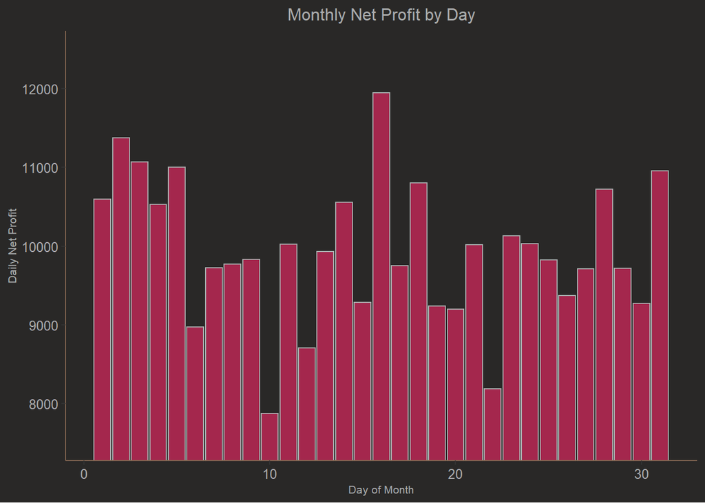

```r
#color palette

col.pal <- c("#a9abac", "#101214", "#c32757", "#462b36", "#109d47", "#806450", "#7c2487", "#292827", "#cf7923")


gg.Profits.month <- ggplot(DailySales) +
  geom_bar(aes(Day,Net),stat="identity", col=col.pal[1],fill=col.pal[3],alpha = 0.8)+
  labs(x="Day of Month",y="Daily Net Profit", title = "Monthly Net Profit by Day")+
  coord_cartesian(ylim=c(min(DailySales$Net)*0.955,max(DailySales$Net)*1.045))+
  theme_hc() +
  theme(plot.title = element_text(hjust = 0.5, size = 12, color = col.pal[1]),
        axis.title = element_text(size=8, color = col.pal[1]),
        axis.text = element_text(color = col.pal[1]),
        legend.text = element_text(size = 8, color = col.pal[1]),
        legend.title = element_text(size = 8, color = col.pal[1]),
        plot.background = element_rect(fill = col.pal[8]),
        legend.background = element_rect(fill = col.pal[8]),
        axis.line = element_line(colour = col.pal[6],
                      size = 0.5, linetype = "solid"),
        panel.grid.major.y = element_blank())

gg.Profits.month
```

##### Product Breakdown

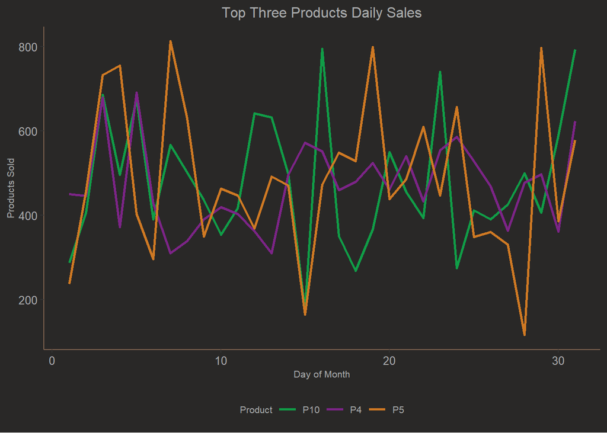

```r
Pro.day <- data.frame(Product = as.numeric())

for (i in 1:31) {

  Pro.day.f <- SalesData %>% filter(Day == i) %>% group_by(Product) %>% summarise(n=sum(Count))

  Pro.day.f$Day <- i

  Pro.day <- rbind(Pro.day,Pro.day.f)

}

Pro.tot <- SalesData %>% group_by(Product) %>% summarise(n=sum(Count))

Pro.tot <- data.frame(Pro.tot[order(-Pro.tot$n),])

Pro.day$Product <- paste("P", Pro.day$Product, sep = "")

Pro.tot$Product <- paste("P", Pro.tot$Product, sep = "")

gg.Top.pro <- ggplot(Pro.day %>% filter(Product == Pro.tot[1,1] | Product == Pro.tot[2,1] | Product == Pro.tot[3,1]), aes(x=Day, y=n, color = Product)) +
  geom_line(size = 1)+
  labs(x="Day of Month",y="Products Sold", title = "Top Three Products Daily Sales", fill = "")+
  theme_hc() +
  theme(plot.title = element_text(hjust = 0.5, size = 12, color = col.pal[1]),
        axis.title = element_text(size=8, color = col.pal[1]),
        axis.text = element_text(color = col.pal[1]),
        legend.text = element_text(size = 8, color = col.pal[1]),
        legend.title = element_text(size = 8, color = col.pal[1]),
        plot.background = element_rect(fill = col.pal[8]),
        legend.background = element_rect(fill = col.pal[8]),
        axis.line = element_line(colour = col.pal[6],
                      size = 0.5, linetype = "solid"),
        panel.grid.major.y = element_blank()) +
  scale_color_manual(values=c(col.pal[5], col.pal[7], col.pal[9]))

gg.Top.pro
```

##### Targets

In a realistic scenario, we would have sales targets for the month. Here, because this is a fictional situation, we do not know those values. However we will create them to showcase how a graph to display targets could look.

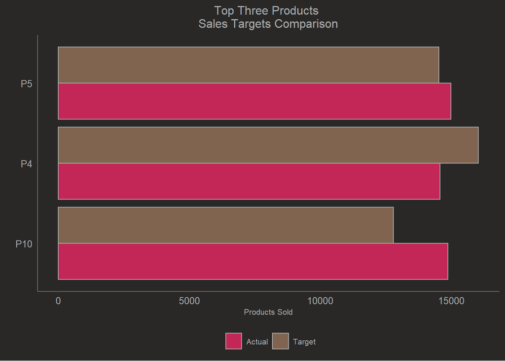

```r
Pro.tot.tar <- Pro.tot[1:3,]

Pro.tot.tar <- rbind(Pro.tot.tar, data.frame(Product = Pro.tot.tar[,1],
                                n = c(round(0.97*Pro.tot[1,2],0), round(0.86*Pro.tot[2,2],0), round(1.1*Pro.tot[3,2],0))))

Pro.tot.tar$Class <- rep(c("Actual","Target"),each=3)

gg.Pro.tar <- ggplot(Pro.tot.tar, aes(x=Product, y=n, fill = Class))+
  geom_bar(position="dodge",stat="identity", col = col.pal[1])+
  coord_flip()+
  labs(x="",y="Products Sold",title=paste("Top Three Products \nSales Targets Comparison", sep = "\n"))+
  theme_hc() +
  theme(plot.title = element_text(hjust = 0.5, size = 12, color = col.pal[1]),
        axis.title = element_text(size=8, color = col.pal[1]),
        axis.text = element_text(color = col.pal[1]),
        legend.text = element_text(size = 8, color = col.pal[1]),
        legend.title = element_text(size = 8, color = col.pal[1]),
        plot.background = element_rect(fill = col.pal[8]),
        legend.background = element_rect(fill = col.pal[8]),
        axis.line = element_line(colour = col.pal[6],
                      size = 0.5, linetype = "solid"),
        panel.grid.major.y = element_blank())+
  guides(fill=guide_legend(title="")) +
  scale_fill_manual(values=c(col.pal[3], col.pal[6]))

gg.Pro.tar
```

##### Final Product

To pull this all together, we can create a simple infographic that pulls together all of the necessary information. If we were to take this further, we might consider building a Shiny dashboard that allows interactive displays, or, for a more complete graphic displayed to external shareholders we might bring individual elements into a product such as Adobe for more precise editing.

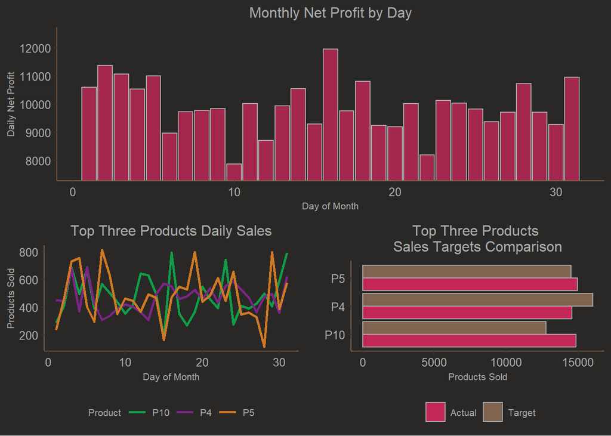

```r
ggarrange(gg.Profits.month,
          ggarrange(
            gg.Top.pro, gg.Pro.tar),
          nrow=2)
```

### Conclusions

Overall, this document demonstrates the power of using R to easily take something as simple as a CSV of weekly sales and turn it into a powerful, simply weekly checkup tool. With more time and a specific goal, a complex analysis could be created. A check could even be incorporated to indicate whether a long or short report was desired. And, as mentioned earlier, this could easily be built as a R Shiny dashboard which would allow for a more interactive display and analysis. Once written, this code can be run as many times as needed, without any changes, and will provide a consistent report that can be cataloged and compared to past months. Raw number analysis can also be exported and automatically saved to folders named after the week or month the report was run for.  
In the end, R provides a powerful tool to allow us to quickly, efficiently, and consistently review the large volumes of data every organization now encounters, and because it is relatively simple to work with it can be tailored to each individual task without issue.

### Contact Information

Thank you for taking time to peruse my analysis. While this is a science, it can also fall into the category of an art form. If you would like to contact me for any reason, please feel free to reach me at my email:

Email: joshuapcullum@gmail.com

Even if you would like to touch base on something unrelated to employment, feel free to reach out. While this is my portfolio, I am always interested to connect with others in my field, and am always open to constructive criticism.

GitHub: https://github.com/jpcullum

LinkedIn: https://www.linkedin.com/in/josh-cullum-74891722b/

Portfolio Website: https://jpcullum.github.io/

End Document